Name: Syafiera (石菲樂)

Student ID: G12460770

# Analyzing Monthly Sales Data

In this occasion, we are about to analyse the data set of the monthly sales in order to understand the sales trends. Firstly, we must ensure that we installed Pandas and Matplotlib extensions before we run this project.

**1. Load the Dataset**

We begin by loading the dataset from CSV file ‘monthly_sales.csv’ into Pandas DataFrame as you may see below;

```python
import pandas as pd
import matplotlib.pyplot as plt
```

import pandas and matplotlib to read the dataset correctly and run accordingly.

```python
df = pd.read_csv('monthly_sales.csv')
```

create df (DataFrame) to read the dataset of monthly sales from csv file

After we read the data from csv, we will see that this file contains two columns which are ‘Month’ that represent the month of the year, and ‘Sales’ that represent the total sales for that month.

```python
df.info()
```

```
<class 'pandas.core.frame.DataFrame'>
RangeIndex: 12 entries, 0 to 11
Data columns (total 2 columns):
 #   Column  Non-Null Count  Dtype
---  ------  --------------  -----
 0   Month   12 non-null     object
 1   Sales   12 non-null     int64
dtypes: int64(1), object(1)
memory usage: 324.0+ bytes
```

```python
df.head(12)
```

|  | Month | Sales |
| --- | --- | --- |
| 0 | January | 1000 |
| 1 | February | 1500 |
| 2 | March | 1200 |
| 3 | April | 1700 |
| 4 | May | 1600 |
| 5 | June | 1800 |
| 6 | July | 2000 |
| 7 | August | 1900 |
| 8 | September | 2200 |
| 9 | October | 2100 |
| 10 | November | 2300 |
| 11 | December | 2500 |

**2. Data Cleaning**

Once the data is loaded and we know how many data that we would like to proceed, then we can continue to do Data Cleaning by checking for any missing values, if any missing values are detected, we will handle them by dropping the rows containing the missing values to ensure the dataset is complete and accurate for further analysis. Let see whether the dataset provided has missing values as you may see below,

```python
df.isnull().sum()
```

```
Month    0
Sales    0
dtype: int64
```

this data turns out have no missing values found.

**3. Explanatory Data Analysis (EDA)**

Next, we can conduct EDA to derive basic statistics from the dataset. We can calculate the total sales across all months and determine the average monthly sales. Additionally, we can identify the month with the highest sales and the month with the lowest sales by locating the maximum and minimum values in the ‘Sales’ column.

Total Sales

In this part we generate the total sales of the dataset.

```python
total_sales = df['Sales'].sum()
print(total_sales)
```

```
21800
```

Average Sales

This part we generate the average sales of the dataset.

```python
average_sales = df['Sales'].mean()
print(average_sales)
```

```
1816.6666666666667
```

Highest Sales

This part we generate the highest sales of the dataset.

```python
highest_sales = df['Sales'].max()
print(highest_sales)
```

```
2500
```

Lowest Sales

This part we generate the lowest sales of the dataset.

```python
lowest_sales = df['Sales'].min()
print(lowest_sales)
```

```
1000
```

Identify the Month With Highest Sales

```python
highest_sales_month = df.loc[df['Sales'].idxmax(), 'Month']
print(highest_sales_month)
```

```
December
```

Identify the month with lowest sales

```python
lowest_sales_month = df.loc[df['Sales'].idxmin(), 'Month']
print(lowest_sales_month)
```

```
January
```

In conclusion, we can print the basic data statistics for a better understanding of the sales trend.

```python
print(f"Total Sales: {total_sales}")
print(f"Average Sales: {average_sales}")
print(f"Highest Sales: {highest_sales} in {highest_sales_month}")
print(f"Lowest Sales: {lowest_sales} in {lowest_sales_month}")
```

```
Total Sales: 21800
Average Sales: 1816.6666666666667
Highest Sales: 2500 in December
Lowest Sales: 1000 in January
```

Other than above data, we can also calculate using 1 simple python line as you may see below;

```python
df.describe()
```

|  | Sales |
| --- | --- |
| count | 12.000000 |
| mean | 1816.666667 |
| std | 444.835686 |
| min | 1000.000000 |
| 25% | 1575.000000 |
| 50% | 1850.000000 |
| 75% | 2125.000000 |
| max | 2500.000000 |

However, this code does not define a detail of which month in the dataset has highest and lowest sales throughout the year. So, in this occasion I would prefer to use the function that manually calculate basic statistics.

**4. Data Visualization**

For Data Visualization, we create a line plot to illustrate the sales trend over the months. Using Matplotlib, we plot the months on the x-axis and the corresponding sales figure on the y-axis. This plot helps to visually assess how sales fluctuate throughout the year, highlighting any patterns or trends. The plot is customized with markers and a grid for clarity, and the month labels on the x-axis are rotated for a better readability.

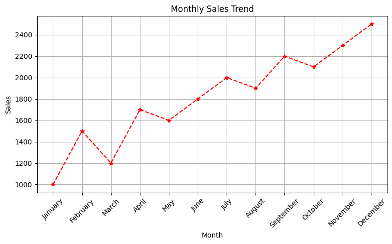

```python
plt.figure(figsize=(8, 5))
plt.plot(df['Month'], df['Sales'], marker='*', linestyle='--', color='r')
plt.title('Monthly Sales Trend')
plt.xlabel('Month')
plt.ylabel('Sales')
plt.xticks(rotation=45)
plt.grid(True)
plt.tight_layout()
plt.show()
```

**Conclusion**

This comprehensive analysis not only provides insights into the sales performance over different months but also allows us to identify peak sales periods and months where sales are lower, aiding in better decision-making and strategic planning.